# Homework 5 - Jacob Igel

Last complied on April 03, 2023

1. Suppose that before we conducted a study to compare versions A and B, we knew we’d do a subgroup analysis, with one subgroup for viewed from email and another for viewed by Internet. We expected to get 50 observations for email and 271 of each version for Internet. Based on experience, we knew the standard deviation of each subgroup to be 30. What is the power for each subgroup if we wish to detect a difference of $5? $10? $15? Comment on the power of each subgroup.

# Email

```r
#A
power.t.test(n=50, delta=5, sd=30, sig.level=0.05, power = NULL)
```

```
##
##      Two-sample t test power calculation
##
##               n = 50
##           delta = 5
##              sd = 30
##       sig.level = 0.05
##           power = 0.1282352
##     alternative = two.sided
##
## NOTE: n is number in *each* group
```

```r
#B
power.t.test(n=50, delta=10, sd=30, sig.level=0.05, power = NULL)
```

```
##
##      Two-sample t test power calculation
##
##               n = 50
##           delta = 10
##              sd = 30
##       sig.level = 0.05
##           power = 0.3784221
##     alternative = two.sided
##
## NOTE: n is number in *each* group
```

```r
#C
power.t.test(n=50, delta=15, sd=30, sig.level=0.05, power = NULL)
```

```
##
##      Two-sample t test power calculation
##
##               n = 50
##           delta = 15
##              sd = 30
##       sig.level = 0.05
##           power = 0.6968888
##     alternative = two.sided
##
## NOTE: n is number in *each* group
```

- A: The power would be 0.12 for this test and there would be a 88% probability that we decided there is no difference when there actually is a difference of $5 in sales between the two groups.
- B: The power would be 0.38 for this test and there would be a 62% probability that we decided there is no difference when there actually is a difference of $10 in sales between the two groups.
- C: The power would be 0.69 for this test and there would be a 31% probability that we decided there is no difference when there actually is a difference of $15 in sales between the two groups.

# Internet

```r
#D
power.t.test(n=271, delta=5, sd=30, sig.level=0.05, power = NULL)
```

```
##
##      Two-sample t test power calculation
##
##               n = 271
##           delta = 5
##              sd = 30
##       sig.level = 0.05
##           power = 0.4906894
##     alternative = two.sided
##
## NOTE: n is number in *each* group
```

```r
#E
power.t.test(n=271, delta=10, sd=30, sig.level=0.05, power = NULL)
```

```
##
##      Two-sample t test power calculation
##
##               n = 271
##           delta = 10
##              sd = 30
##       sig.level = 0.05
##           power = 0.9721436
##     alternative = two.sided
##
## NOTE: n is number in *each* group
```

```r
#F
power.t.test(n=271, delta=15, sd=30, sig.level=0.05, power = NULL)
```

```
##
##      Two-sample t test power calculation
##
##               n = 271
##           delta = 15
##              sd = 30
##       sig.level = 0.05
##           power = 0.9999409
##     alternative = two.sided
##
## NOTE: n is number in *each* group
```

- D: The power would be 0.49 for this test and there would be a 51% probability that we decided there is no difference when there actually is a difference of $5 in sales between the two groups.
- E: The power would be 0.97 for this test and there would be a 3% probability that we decided there is no difference when there actually is a difference of $10 in sales between the two groups.
- F: The power would be 0.99 for this test and there would be a 1% probability that we decided there is no difference when there actually is a difference of $15 in sales between the two groups.

1. Read in the data and find the mean and standard deviation for Y at each value of X.

```r
df <- read.csv("/Users/jacobigel/Desktop/School/ISA365-A/Datasets/ttvariables.csv", stringsAsFactors = TRUE)

head(df)
```

```
##        Y X Z1 Z2 Z3 Z4 Z5 Z6 Z7 Z8 Z9 Z10   Z11   Z12   Z13    Z14   Z15   Z16
## 1  7.494 1  0  0  0  0  0  0  1  0  0   0 0.813 0.870 0.857  5.995 1.376 3.782
## 2 10.735 1  0  0  0  0  0  0  1  1  0   0 0.924 0.348 1.664 12.970 0.981 6.876
## 3  6.657 1  0  0  0  0  0  1  0  1  0   0 0.353 0.372 0.074 14.582 0.647 0.830
## 4 16.381 0  0  0  1  0  0  0  0  0  1   1 0.478 0.319 0.054  3.475 0.242 5.728
## 5 11.318 0  0  1  0  1  0  1  0  0  1   0 0.545 0.684 3.238  2.535 1.118 3.737
## 6  6.718 0  0  0  0  0  1  0  1  0  1   1 0.878 0.632 0.051  3.102 0.298 3.628
##     Z17   Z18   Z19   Z20
## 1 1.498 1.690 2.015 5.445
## 2 2.445 1.031 2.342 7.517
## 3 1.368 0.526 2.738 9.343
## 4 0.153 1.307 3.255 7.647
## 5 2.174 0.919 3.067 5.240
## 6 0.362 1.400 3.985 6.259
```

```r
library(dplyr)
library(magrittr)

df %>% group_by(X) %>% summarise(mean(Y), sd(Y), n())
```

```
## # A tibble: 2 × 4
##       X `mean(Y)` `sd(Y)` `n()`
##   <int>     <dbl>   <dbl> <int>
## 1     0     10.1     4.22   500
## 2     1      9.83    4.05   500
```

2. The treatment had no effect. Perform a test to verify this.

```r
t.test(df$Y~df$X)
```

```
##
##  Welch Two Sample t-test
##
## data:  df$Y by df$X
## t = 0.94903, df = 996.34, p-value = 0.3428
## alternative hypothesis: true difference in means between group 0 and group 1 is not equal to 0
## 95 percent confidence interval:
##  -0.2653141  0.7622821
## sample estimates:
## mean in group 0 mean in group 1
##       10.077652        9.829168
```

3. The variables Z1 through Z10 are binary covariates. Change them so they are correctly coded in r.

```r
df$Z1 <- as.factor(df$Z1)
df$Z2 <- as.factor(df$Z2)
df$Z3 <- as.factor(df$Z3)
df$Z4 <- as.factor(df$Z4)
df$Z5 <- as.factor(df$Z5)
df$Z6 <- as.factor(df$Z6)
df$Z7 <- as.factor(df$Z7)
df$Z8 <- as.factor(df$Z8)
df$Z9 <- as.factor(df$Z9)
df$Z10 <- as.factor(df$Z10)
```

4. Test to see if any of these covariates has a significant effect. You will have to perform two tests per variable, one for the “1” group and one for the “0” group. Do this for each covariate Z1 through Z10. Hint: I would use `filter()` from tidyverse to make small little datasets and then perform the t.tests.

# Group 1

```r
library(tidyverse)

df1 <- filter(df, Z1 == 1)
t.test(df1$Y ~ df1$X)
```

```
##
##  Welch Two Sample t-test
##
## data:  df1$Y by df1$X
## t = -1.8498, df = 43.506, p-value = 0.07114
## alternative hypothesis: true difference in means between group 0 and group 1 is not equal to 0
## 95 percent confidence interval:
##  -4.6890354  0.2015816
## sample estimates:
## mean in group 0 mean in group 1
##        8.981304       11.225031
```

```r
df2 <- filter(df, Z2 == 1)
t.test(df2$Y ~ df2$X)
```

```
##
##  Welch Two Sample t-test
##
## data:  df2$Y by df2$X
## t = -1.1995, df = 110.94, p-value = 0.2329
## alternative hypothesis: true difference in means between group 0 and group 1 is not equal to 0
## 95 percent confidence interval:
##  -2.2722362  0.5586687
## sample estimates:
## mean in group 0 mean in group 1
##        9.641426       10.498210
```

```r
df3 <- filter(df, Z3 == 1)
t.test(df3$Y ~ df3$X)
```

```
##
##  Welch Two Sample t-test
##
## data:  df3$Y by df3$X
## t = -1.7499, df = 150.61, p-value = 0.08217
## alternative hypothesis: true difference in means between group 0 and group 1 is not equal to 0
## 95 percent confidence interval:
##  -2.5411950  0.1541118
## sample estimates:
## mean in group 0 mean in group 1
##         9.85669        11.05023
```

```r
df4 <- filter(df, Z4 == 1)
t.test(df4$Y ~ df4$X)
```

```
##
##  Welch Two Sample t-test
##
## data:  df4$Y by df4$X
## t = 2.161, df = 216.62, p-value = 0.03179
## alternative hypothesis: true difference in means between group 0 and group 1 is not equal to 0
## 95 percent confidence interval:
##  0.1100212 2.3922440
## sample estimates:
## mean in group 0 mean in group 1
##       10.986615        9.735483
```

```r
df5 <- filter(df, Z5 == 1)
t.test(df5$Y ~ df5$X)
```

```
##
##  Welch Two Sample t-test
##
## data:  df5$Y by df5$X
## t = 1.4628, df = 241.26, p-value = 0.1448
## alternative hypothesis: true difference in means between group 0 and group 1 is not equal to 0
## 95 percent confidence interval:
##  -0.2669386  1.8069555
## sample estimates:
## mean in group 0 mean in group 1
##       10.703000        9.932992
```

```r
df6 <- filter(df, Z6 == 1)
t.test(df6$Y ~ df6$X)
```

```
##
##  Welch Two Sample t-test
##
## data:  df6$Y by df6$X
## t = -0.16523, df = 282.94, p-value = 0.8689
## alternative hypothesis: true difference in means between group 0 and group 1 is not equal to 0
## 95 percent confidence interval:
##  -1.1052686  0.9340814
## sample estimates:
## mean in group 0 mean in group 1
##        9.900153        9.985747
```

```r
df7 <- filter(df, Z7 == 1)
t.test(df7$Y ~ df7$X)
```

```
##
##  Welch Two Sample t-test
##
## data:  df7$Y by df7$X
## t = -1.1981, df = 306.38, p-value = 0.2318
## alternative hypothesis: true difference in means between group 0 and group 1 is not equal to 0
## 95 percent confidence interval:
##  -1.4587898  0.3546138
## sample estimates:
## mean in group 0 mean in group 1
##        9.521329       10.073417
```

```r
df8 <- filter(df, Z8 == 1)
t.test(df8$Y ~ df8$X)
```

```
##
##  Welch Two Sample t-test
##
## data:  df8$Y by df8$X
## t = 0.94802, df = 415.86, p-value = 0.3437
## alternative hypothesis: true difference in means between group 0 and group 1 is not equal to 0
## 95 percent confidence interval:
##  -0.4126292  1.1814069
## sample estimates:
## mean in group 0 mean in group 1
##        9.998624        9.614235
```

```r
df9 <- filter(df, Z9 == 1)
t.test(df9$Y ~ df9$X)
```

```
##
##  Welch Two Sample t-test
##
## data:  df9$Y by df9$X
## t = 1.1642, df = 435.7, p-value = 0.245
## alternative hypothesis: true difference in means between group 0 and group 1 is not equal to 0
## 95 percent confidence interval:
##  -0.3185385  1.2443039
## sample estimates:
## mean in group 0 mean in group 1
##       10.241291        9.778408
```

```r
df10 <- filter(df, Z10 == 1)
t.test(df10$Y ~ df10$X)
```

```
##
##  Welch Two Sample t-test
##
## data:  df10$Y by df10$X
## t = 1.054, df = 484.2, p-value = 0.2924
## alternative hypothesis: true difference in means between group 0 and group 1 is not equal to 0
## 95 percent confidence interval:
##  -0.3444279  1.1415117
## sample estimates:
## mean in group 0 mean in group 1
##       10.224428        9.825886
```

# Group 0

```r
library(tidyverse)

df01 <- filter(df, Z1 == 0)
t.test(df01$Y ~ df01$X)
```

```
##
##  Welch Two Sample t-test
##
## data:  df01$Y by df01$X
## t = 1.4806, df = 942.63, p-value = 0.139
## alternative hypothesis: true difference in means between group 0 and group 1 is not equal to 0
## 95 percent confidence interval:
##  -0.1291371  0.9227199
## sample estimates:
## mean in group 0 mean in group 1
##       10.130516        9.733724
```

```r
df02 <- filter(df, Z2 == 0)
t.test(df02$Y ~ df02$X)
```

```
##
##  Welch Two Sample t-test
##
## data:  df02$Y by df02$X
## t = 1.4099, df = 881.48, p-value = 0.1589
## alternative hypothesis: true difference in means between group 0 and group 1 is not equal to 0
## 95 percent confidence interval:
##  -0.1552627  0.9472730
## sample estimates:
## mean in group 0 mean in group 1
##       10.130469        9.734463
```

```r
df03 <- filter(df, Z3 == 0)
t.test(df03$Y ~ df03$X)
```

```
##
##  Welch Two Sample t-test
##
## data:  df03$Y by df03$X
## t = 1.861, df = 842.75, p-value = 0.06309
## alternative hypothesis: true difference in means between group 0 and group 1 is not equal to 0
## 95 percent confidence interval:
##  -0.02869694  1.07788145
## sample estimates:
## mean in group 0 mean in group 1
##       10.114221        9.589629
```

```r
df04 <- filter(df, Z4 == 0)
t.test(df04$Y ~ df04$X)
```

```
##
##  Welch Two Sample t-test
##
## data:  df04$Y by df04$X
## t = -0.063426, df = 777.49, p-value = 0.9494
## alternative hypothesis: true difference in means between group 0 and group 1 is not equal to 0
## 95 percent confidence interval:
##  -0.5921659  0.5550971
## sample estimates:
## mean in group 0 mean in group 1
##        9.838934        9.857469
```

```r
df05 <- filter(df, Z5 == 0)
t.test(df05$Y ~ df05$X)
```

```
##
##  Welch Two Sample t-test
##
## data:  df05$Y by df05$X
## t = 0.2317, df = 750.63, p-value = 0.8168
## alternative hypothesis: true difference in means between group 0 and group 1 is not equal to 0
## 95 percent confidence interval:
##  -0.5221780  0.6619309
## sample estimates:
## mean in group 0 mean in group 1
##        9.866973        9.797097
```

```r
df06 <- filter(df, Z6 == 0)
t.test(df06$Y ~ df06$X)
```

```
##
##  Welch Two Sample t-test
##
## data:  df06$Y by df06$X
## t = 1.2909, df = 698.39, p-value = 0.1972
## alternative hypothesis: true difference in means between group 0 and group 1 is not equal to 0
## 95 percent confidence interval:
##  -0.2034517  0.9844929
## sample estimates:
## mean in group 0 mean in group 1
##       10.144642        9.754121
```

```r
df07 <- filter(df, Z7 == 0)
t.test(df07$Y ~ df07$X)
```

```
##
##  Welch Two Sample t-test
##
## data:  df07$Y by df07$X
## t = 2.0288, df = 642.53, p-value = 0.04289
## alternative hypothesis: true difference in means between group 0 and group 1 is not equal to 0
## 95 percent confidence interval:
##  0.02092248 1.28192523
## sample estimates:
## mean in group 0 mean in group 1
##       10.334667        9.683243
```

```r
df08 <- filter(df, Z8 == 0)
t.test(df08$Y ~ df08$X)
```

```
##
##  Welch Two Sample t-test
##
## data:  df08$Y by df08$X
## t = 0.48562, df = 578.06, p-value = 0.6274
## alternative hypothesis: true difference in means between group 0 and group 1 is not equal to 0
## 95 percent confidence interval:
##  -0.506259  0.838835
## sample estimates:
## mean in group 0 mean in group 1
##       10.138745        9.972457
```

```r
df09 <- filter(df, Z9 == 0)
t.test(df09$Y ~ df09$X)
```

```
##
##  Welch Two Sample t-test
##
## data:  df09$Y by df09$X
## t = 0.23151, df = 555.22, p-value = 0.817
## alternative hypothesis: true difference in means between group 0 and group 1 is not equal to 0
## 95 percent confidence interval:
##  -0.6037766  0.7651181
## sample estimates:
## mean in group 0 mean in group 1
##        9.949079        9.868408
```

```r
df010 <- filter(df, Z10 == 0)
t.test(df010$Y ~ df010$X)
```

```
##
##  Welch Two Sample t-test
##
## data:  df010$Y by df010$X
## t = 0.27126, df = 504.12, p-value = 0.7863
## alternative hypothesis: true difference in means between group 0 and group 1 is not equal to 0
## 95 percent confidence interval:
##  -0.6164905  0.8139916
## sample estimates:
## mean in group 0 mean in group 1
##        9.930876        9.832125
```

5. Which subgroups show an effect?
- df4: The ones group in Z4
- df07: The zero group in Z7
6. What is the probability that at least one of those tests is a type I error?

```r
1 - .95^20
```

```
## [1] 0.6415141
```

7. The variables Z11-Z20 are continuous. The first step is to determine possible cut off values. It might be helpful to make a histogram of the variable to see if there are some “natural” groups. Make a histogram of Z11.

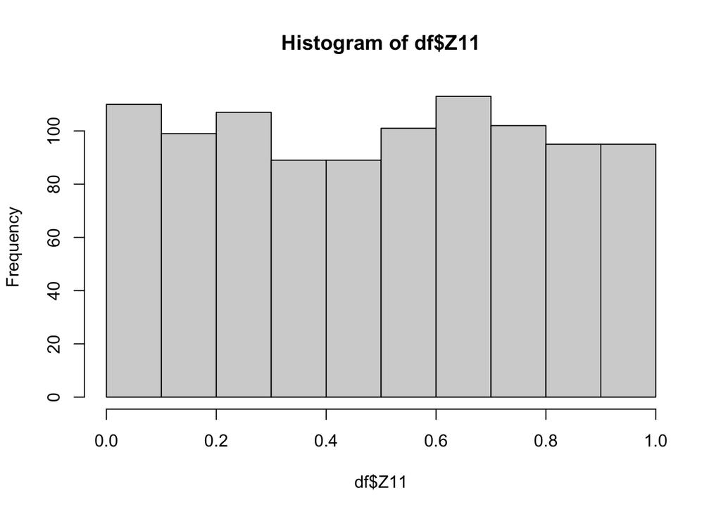

```r
hist(df$Z11)
```

8. Let’s break down Z11 into three groups, 0<0.2, 0.2<Z11<0.8 and Z11>0.8. Then we will use those groups and preform a t-test for each group. There is code below. Explain what the first three lines of code are doing. Then write your conclusion about the subgroups.

```r
A<-(df$Z11< 0.2)
B<- (df$Z11 > 0.2) & (df$Z11 <.8)
C<- (df$Z11 > 0.8)
t.test(df$Y[A]~df$X[A])
t.test(df$Y[B]~df$X[B])
t.test(df$Y[C]~df$X[C])
```

[output not shown]

```r
prop.test( x = c(830, 970), n = c(14000, 14000))
```

```
##
##  2-sample test for equality of proportions with continuity correction
##
## data:  c(830, 970) out of c(14000, 14000)
## X-squared = 11.471, df = 1, p-value = 0.0007068
## alternative hypothesis: two.sided
## 95 percent confidence interval:
##  -0.015815736 -0.004184264
## sample estimates:
##     prop 1     prop 2
## 0.05928571 0.06928571
```

- From this test that we preformed, we can see that this result is significant and that version B is the best. My recommendation is to continue using version B since it saw the most conversion rate on the webpage.
11. Your boss, who is an MU grad, calls you into his office. He has checked the source of the referrals to the landing page. He shows you the following:

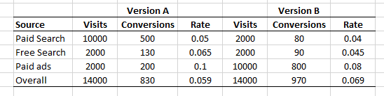

“So version A does better on each source, but does worse overall? What is the meaning of this? Should we implement version A or version B?”. How do you answer your boss?

- Well boss, even though we can see from the whole data set that A does better on each source but if we are wanting to predict what would be better for us in the long term, we would want to choose version B.